Montroy *et al. BMC Gastroenterol (2020) 20:372*

https://doi.org/10.1186/s12876-020-01516-4

**RESEARCH ARTICLE**

The effects of resistant starches

on inflammatory bowel disease in preclinical

and clinical settings: a systematic review

and meta-analysis

Joshua Montroy<sup>1</sup>, Rania Berjawi<sup>1,2</sup>, Manoj M. Lalu<sup>1,3</sup>, Eyal Podolsky<sup>1,2</sup>, Cayden Peixoto<sup>2</sup>, Levent Sahin<sup>1</sup>,

Alain Stintzi<sup>4</sup>, David Mack<sup>5</sup> and Dean A. Fergusson<sup>1,2,6*</sup>

**Abstract**

**Background:** Inflammatory bowel disease (IBD) is a debilitating chronic disease with limited treatment options.

Resistant starches may represent a novel treatment for IBD. However, its efficacy and safety remain unclear. Our objec-

tive was to perform a systematic review to summarize the preclinical and clinical effects of resistant starch, which may

help guide future studies.

**Methods:** Medline, EMBASE, and the Cochrane Central Register were searched. Included studies investigated the use

of resistant starch therapy in in vivo animal models of IBD or human patients with IBD. Articles were screened, and

data extracted, independently and in duplicate. The primary outcomes were clinical remission (clinical) and bowel

mucosal damage (preclinical).

**Results:** 21 preclinical (n = 989 animals) and seven clinical (n = 164 patients) studies met eligibility. Preclinically,

resistant starch was associated with a significant reduction in bowel mucosal damage compared to placebo (stand-

ardized mean difference − 1.83, 95% CI − 2.45 to − 1.20). Clinically, five studies reported data on clinical remission

but clinical and methodological heterogeneity precluded pooling. In all five, a positive effect was seen in patients

who consumed resistant starch supplemented diets. The majority of studies in both the preclinical and clinical set-

tings were at a high or unclear risk of bias due to poor methodological reporting.

**Conclusions:** Our review demonstrates that resistant starch is associated with reduced histology damage in animal

studies, and improvements in clinical remission in IBD patients. These results need to be tempered by the risk of bias

of included studies. Rigorously designed preclinical and clinical studies are warranted.

Trial registration

The review protocols were registered on PROSPERO (preclinical: CRD42019130896; clinical: CRD42019129513).

**Keywords:** Inflammatory bowel disease, Resistant starch, Systematic review

© The Author(s) 2020. **Open Access** This article is licensed under a Creative Commons Attribution 4.0 International License, which

permits use, sharing, adaptation, distribution and reproduction in any medium or format, as long as you give appropriate credit to the

original author(s) and the source, provide a link to the Creative Commons licence, and indicate if changes were made. The images or

other third party material in this article are included in the article’s Creative Commons licence, unless indicated otherwise in a credit line

to the material. If material is not included in the article’s Creative Commons licence and your intended use is not permitted by statutory

regulation or exceeds the permitted use, you will need to obtain permission directly from the copyright holder. To view a copy of this

licence, visit http://creat iveco mmons .org/licen ses/by/4.0/. The Creative Commons Public Domain Dedication waiver (http://creat iveco

mmons .org/publi cdoma in/zero/1.0/) applies to the data made available in this article, unless otherwise stated in a credit line to the data.

**Background**

Inflammatory bowel disease (IBD) is a chronic inflam-

matory condition, the prevalence of which is increas-

ing worldwide [1, 2]. The two dominant subtypes of

IBD are ulcerative colitis (UC) and Crohn’s disease

(CD), which can differ in the location of inflammation

**Open Access**

[figure not shown]

*Correspondence: dafergusson@ohri.ca

1 Clinical Epidemiology Program, Ottawa Hospital Research Institute,

Ottawa, Canada

Full list of author information is available at the end of the article

Page 2 of 14

Montroy *et al. BMC Gastroenterol (2020) 20:372*

within the digestive tract and clinical symptoms but

also can have colonic disease involvement and over-

lapping symptomatology. Current available treatment

options include aminosalicylates [3], immunomodula-

tors [4], corticosteroids [5], biologic agents [6], dietary

changes [7], and surgical interventions [8]. However,

none of these treatments are curative, and have been

known to be associated with adverse effects [9–11].

Effective, less costly and more tolerable treatment

options are currently needed in the long-term treat-

ment of IBD.

Dietary fibres, such as resistant starches (RS) are a

promising therapeutic for IBD [12]. Resistant starches

avoid digestion in the small intestine and are subse-

quently fermented in the large intestine [13]. Since

resistant starch is a natural source of fibre commonly

found in many foods (i.e. potatoes, plantains and leg-

umes), it is easily accessible and may provide an attrac-

tive treatment option (especially in regions of the gut

where the microbial fermentation of RS occurs) due

to high tolerability and few if any adverse effects com-

pared to pharmaceutical options. They are classified

into five categories (RS 1–5) based on their chemical

and physical properties. In pre-clinical animal models

of IBD, resistant starch has demonstrated the ability to

improve the microbiome by increasing the concentra-

tion of short-chain fatty acids and decreasing gut pH

level, which provides a less favourable environment for

microbial pathogens and pathobionts to thrive [14].

They have also been shown to have a positive effect

on inflammation in IBD (i.e. decreases in both inflam-

matory cell infiltration and circulating cytokine levels)

[15–17]. In the clinical human trials, evidence has been

mixed, with RS being found to reduce diarrhea, consti-

pation and induce tissue repair in individuals with IBD

[7], but demonstrating no positive effects in others [18,

19].

In healthy adults ingesting RS, systematic reviews

evidence demonstrates an increased fecal wet weight,

and butyrate concentration while decreasing fecal pH

[20]. However, the evidence of potential efficacy and

safety of RS in the treatment of IBD has yet to be for-

mally synthesized in either the clinical human or pre-

clinical (i.e. animal model) settings. Performing an

evaluation of existing preclinical and clinical evidence

of the effects of RS for IBD will provide a current over-

view of RS therapy across the preclinical to clinical

translational spectrum, help identify knowledge gaps

and guide the design of future investigations. Therefore,

the purpose of this review is to evaluate the effect of RS

on animals and humans with IBD by measuring clinical

remission and histopathological changes compared to

other treatments or placebo.

**Methods**

The review protocols were registered on PROS-

PERO

(preclinical:

CRD42019130896;

clinical:

CRD42019129513). This manuscript followed the report-

ing guidelines set by Preferred Reporting Items for

Systematic Reviews and Meta-Analyses (PRISMA) state-

ment [21].

**Eligibility criteria**

Eligibility criteria for preclinical animal studies included

controlled comparison studies that investigated the

effect of RS compared to placebo, alternative treatments,

or no active treatment in in vivo animal models of IBD.

Exclusion criteria included animal models that do not

represent IBD, studies with no comparison group, and

in vitro or ex vivo studies. For human clinical studies, we

included all interventional studies of IBD patients admin-

istered any form of RS. Interventional studies did not

need to include a comparator arm. Observational studies,

case reports, and case series were excluded. Only full text

studies were considered (i.e., unpublished grey literature,

abstracts, conference abstracts, commentaries, letters,

reviews and editorials were excluded).

**Outcomes**

The primary outcome for the preclinical studies was

mucosal damage as assessed by histology. The second-

ary outcomes were myeloperoxidase activity (a measure

of neutrophil infiltration), short-chain fatty acid produc-

tion, and body weight. Tertiary outcomes were circulat-

ing cytokine levels and gut microbiome changes. The

primary outcome of interest for clinical studies was clini-

cal remission or response rates. The secondary outcomes

included stool consistency and frequency, short-chain

fatty acid production and inflammation (C-reactive pro-

tein). Tertiary outcomes included adverse events, with-

drawal due to adverse events, and serious adverse events.

**Search strategy**

We conducted two systematic literature searches (i.e.

preclinical and clinical) in collaboration with an infor-

mation specialist (Risa Shorr, MLS, Learning Services,

The Ottawa Hospital). Both searches were conducted on

MEDLINE (OVID interface, including In-Process and

Epub Ahead of Print) and Embase (OVID interface), and

additional searches were done to identify clinical studies

in the ClinicalTrials.gov and Cochrane Central Register

of Controlled Trials (Wiley interface). A Peer Review of

Electronic Search Strategies (PRESS) was performed by

a second information specialist who was not associated

respectively. There were no restrictions on language

Page 3 of 14

Montroy *et al. BMC Gastroenterol (2020) 20:372*

or year of publication. We examined reference lists of

included clinical studies and relevant reviews identified

through the search, in order to identify any additional

relevant references. The complete search strategies can

be found in Additional file 1: Appendix I.

**Study selection and data extraction**

Abstract/title, full text screening and data extraction was

done in duplicate by two independent reviewers using

pre-established eligibility criteria. Data extraction forms

for both clinical and preclinical studies were pilot-tested

on five studies prior to proceeding to extracting data

from all studies to ensure agreement between review-

ers. Disagreements between reviewers at any stage of the

review were resolved by discussion or with a third-party

member if a consensus could not be reached. Data items

extracted included study population and intervention

characteristics, along with data pertaining to our out-

comes of interest, and risk of bias details.

**Risk of bias assessment**

The Systematic Review Center for Laboratory Animal

Experimentation (SYRCLE) risk of bias tool was used

in the preclinical review and the Cochrane Risk of Bias

(RoB 2.0) was used for the clinical review [23, 24]. Risk

of bias was assessed in duplicate by two independent

reviewers in each of the two reviews. Disagreements

were resolved first by discussion and if consensus was

not obtained, a consulting a third-party member made

the final judgement. Graphical representations of risk of

bias of included studies were conducted using RevMan

5.3 (Cochrane Collaboration, Oxford, United Kingdom).

**Data analysis**

Studies were pooled using Comprehensive Meta-Ana-

lyst (version 3; Biostat Inc., USA). For continuous out-

comes, a mean difference (MD) or standardized mean

difference (SMD) was calculated, dependent on the

outcome. MD and SMD were calculated using ran-

dom effects inverse variance meta-analyses and pre-

sented with accompanying 95% confidence intervals.

SMD was used to analyze outcomes where heteroge-

neity exists in the method of outcome measurement

(i.e. differing scales). Dichotomous outcomes were

analyzed using a random effects meta-analysis based

on the DerSimonian Laird model, and reported as risk

ratios with 95% confidence intervals (CI). Statistical

heterogeneity was assessed using the Cochrane I<sup>2</sup>sta-

tistic. The thresholds for interpretation of I<sup>2</sup> were as

follows: 0–40% low heterogeneity, 30–60% moderate

heterogeneity, 50–90% may represent substantial het-

erogeneity, and 75–100% is considerable heterogeneity.

Data not suitable for inclusion in meta-analyses were

presented descriptively. The presence of publication

bias was assessed using funnel plots, where sufficient

data were available. Where sufficient data were avail-

able, we performed a priori defined subgroup analyses

for the preclinical studies, including type of RS, source

of RS (food source vs. pure form), and animal species.

**Ethical considerations**

Ethics approval was not needed for the conduct of this

study.

**Results**

The literature searches yielded a total of 5,794 unique

studies for title and abstract screening. Following inde-

pendent, duplicate screening of abstract/titles then full-

texts, 21 preclinical studies [15–17, 25–42] and seven

clinical trials [43–49] met inclusion criteria (Fig. 1). The

Clinicaltrials.gov search for the clinical systematic review

yielded 201 trials, however none met the inclusion crite-

ria of this review (see Additional file 1: Appendix II for

details).

**Study characteristics**

The 21 preclinical studies were published between 1999

and 2020 from 10 different countries (Table 1). All studies

the majority of studies were conducted using male ani-

mals only (n = 11). Thirteen articles reported studying

acute colitis models rather than chronic models. IBD

models used included; dextran sodium sulfate (DSS)-

induced (n = 15), trinitrobenzene sulfonic acid (TNBS)-

induced (n = 4), interleukin (IL)-10 knockout (n = 1), and

CD4+ CD4RB T-cell transfer induced (n = 1).

The seven clinical studies were published between

1995 and 2015, with three studies from Japan, two from

Australia, and one each from Sweden and the United

Kingdom (Table 2). The total number of participants

in all seven studies was 164 subjects (median 21, range

6–59). Two studies were single arm trials administering

RS, two were single arm cross-over trials comparing dif-

ferent regimens of RS administration, two were two-arm

trials comparing RS-supplemented diets to regular diets,

and one study was a two-arm cross-over trial comparing

high and low dose RS diets. All studies were in the adult

population, with the majority of studies only including

UC patients (n = 6), while one study had both UC and

CD patients. Four studies recruited patients who were

in a state of clinical remission, and one study recruited

patients who had “no change in disease activity for at

least 4-week prior to trial” regardless of actual disease

status. Two studies recruited UC patients with no other

Page 4 of 14

Montroy *et al. BMC Gastroenterol (2020) 20:372*

specific inclusion criteria reported. Two studies reported

the length of follow-up conducted (six months and two

months).

Records iden�ﬁed through

database searching

(n = 5,793)

Addi�onal records iden�ﬁed

through other sources

(n = 1)

Records a�er duplicates removed

(n = 5,794)

Records screened

(n = 5,794)

Records excluded

(n = 5,580)

Full-text ar�cles assessed

for eligibility

(n = 214)

Full-text ar�cles excluded,

with reasons

(n = 186)

-

Wrong interven�on

(n=95)

-

Wong popula�on (n=41)

-

Abstract only (n=28)

-

Duplicate (n=16)

-

Wrong study design (n=2)

-

Review/commentary

(n=4)

Studies included in

qualita�ve synthesis

(n = 28)

Clinical Studies included in

qualita�ve synthesis

(n = 7)

Preclinical studies

included in qualita�ve

synthesis

(n = 21)

Clinical Studies included in

quan�ta�ve synthesis

(meta-analysis)

(n = 0)

Studies included in

quan�ta�ve synthesis

(meta-analysis)

**Fig. 1** Study selection flow diagram

Page 5 of 14

Montroy *et al. BMC Gastroenterol (2020) 20:372*

**Intervention characteristics**

In preclinical studies, type 3 RS was the most commonly

used (n = 7), while six studies used type 1 RS, sex used

type 2 RS, and two studies used type 5 RS (Table 3). All

studies gave the animals free access to either the RS-

reported inducing colitis in animals after administer-

ing dietary intervention, and four induced colitis dur-

ing access to dietary intervention. Eight studies reported

housing animals individually, and the remaining studies

did not report on animal housing.

Type 1 RS was most commonly investigated in clini-

cal studies (n = 4), while one study used type 2, one study

used a mix of types 1 and 2 and one study used a mix of

types 2 and 3 (Table 4). Sources of RS included germi-

nated barley foodstuff, high-amylose maize starch, oat

RS varied among studies. The lowest dose of RS given to

participants was 0.6 g/day, while the highest was 34.8 g/

day. Of the three cross-over studies, only one mentioned

a wash-out period (14 days).

Adherence to the dietary intervention was reported in

two of the seven clinical studies through diary entries,

returned foods, checklist and compliance records. One

study had an adherence of 88–100% in both control and

intervention groups and the second study reported a

compliance of at least 80% of dietary fiber given. Adher-

ence was not measured in any of the included preclinical

studies.

**Preclinical outcomes**

*Primary outcome*

mals). Administration of RS was associated with a signifi-

cant reduction in histological score compared to control

(SMD − 1.83; 95% CI − 2.45 to − 1.20, I<sup>2</sup> = 77%) (Fig. 2).

Further details on the measurement of histology scores

in individual studies can be found in the appendix (Addi-

tional file 1: Appendix III). A post-hoc sensitivity analy-

sis was performed removing extreme values, given the

presence of an outlier in the analysis. After the removal

of extreme values, RS remained associated with improve-

ments in histological score (Additional file 1: Appendix

IV). A small degree of publication bias was indicated in

the funnel plot and with eggers regression test, however

this is largely driven by a single outlier (Additional file 1:

Appendix V). In our a priori subgroup analyses, the effect

of RS on histological scores did not vary by type of RS,

**Table 1 Characteristics of included preclinical studies**

*DSS* dextran sulfate sodium, *F* female, *M* male, *NR* not reported, *SCID* severe combined immunodeficiency, *TNBS* trinitrobenzene sulfonic acid

**References**

**Host country(ies) Sample size Species IBD model, chronicity**

**Age (weeks) Biological sex (M/F)**

Araki et al. [41]

Japan

40

Rats

DSS-induced, NR

12

M

Araki et al. [29]

Japan

18

Rats

DSS-induced, NR

11

M

Bassaganya-Riera et al. [34]

USA

275

Mice

IL-10 knockout, NR

8

50:50, M/F

Islam et al. [27]

Japan

24

Mice

DSS-induced, acute

10–12

M

Jacobasch et al. [36]

Germany

NR

Rats

TNBS-induced, NR

NR

NR

Kanauchi et al. [39, 40]

Japan

8

Rats

DSS-induced, acute

NR

M

Kanauchi et al. [39, 40]

Japan

8

Rats

DSS-induced, chronic

NR

M

Kanauchi et al. [38, 45]

Japan

20

Mice

DSS induced, acute

9

F

Kanauchi et al. [35]

Japan

16

Mice

CD4+ CD45RB T cell transfer, chronic 5

F

Komiyama et al. [32]

Japan

30

Mice

DSS-induced, acute

9

F

Le Leu et al. [15]

Australia

32

Mice

DSS-induced, acute

NR

M

Majumder et al. [28]

Canada & Japan

24

Mice

DSS-induced, acute

6–8

F

Moreau et al. [17]

France

72

Rats

DSS-induced, chronic

NR

M

Moreau et al. [37]

France

60

Rats

DSS-induced, acute and chronic

NR

M

Morita et al. [16]

Japan

32

Rats

TNBS-induced, acute

NR

M

Panasevich et al. [26]

USA

66

Mice

DSS-induced, acute

8–10

M

Praengam et al. [25]

Thailand

32

Mice

DSS-induced, acute

6

F

Qian et al. [30]

China

40

Mice

DSS-induced, acute

7

F

Rodriguez-Cabezas et al. [33] Spain

50

Rats

TNBS-induced, acute

NR

F

Scarminio et al. [31]

Brazil

72

Rats

TNBS-induced, acute

NR

M

Shinde et al. [42]

Australia

50

Mice

DSS-induced, acute

7

Both

Page 6 of 14

Montroy *et al. BMC Gastroenterol (2020) 20:372*

source of RS (food vs pure), or animal species (Additional

file 1: Appendix IV).

*Secondary outcomes*

MPO activity was measured in six of the included pre-

clinical studies (n = 148 animals). Animals who received

a RS supplemented diet had significantly decreased MPO

concentration, compared to animals who received a con-

trol diet (SMD − 1.21; 95% CI − 1.74 to − 0.69, I<sup>2</sup> = 48%)

(Fig. 3).

Short-chain fatty acid concentration was measured

in nine of the included studies (n = 223 animals). Three

studies did not report data in a manner suitable for

inclusion in the meta-analysis. Short chain fatty acid

concentration increased significantly in RS fed animals,

compared to control (SMD 1.50; 95% CI 0.67 to 2.33,

I<sup>2</sup> = 80%) (Fig. 4).

Body weight was measured in ten of the included stud-

ies (n = 253 animals), with one study not reporting data

in a format suitable for inclusion in the meta-analysis.

Animals fed a RS-supplemented diet had significantly

higher body weights at the end of the experimental

period, compared to animals fed a control diet (SMD

1.00; 95% CI 0.11 to 1.89, I<sup>2</sup> = 83%) (Fig. 5).

*Tertiary outcomes*

Seven of the included studies evaluated cytokine activ-

ity. A pooled analysis could not be performed due to the

**Table 2 Characteristics of included clinical studies**

*GBF* germinated barley foodstuff, *HAMS* high-amylose maize starch, *LAMS* low-amylose maize starch, *N/A* not applicable, *NR* not reported, *RS* resistant starch

§ Age mean (SEM)

† Age of control group

‡ Age of intervention group

**References**

**# centres**

**Sample size**

**(control/**

**intervention)**

**Age**

**of cohort**

**(mean,**

**range)**

**% Male**

**(overall)**

**Follow-up**

**Disease**

**status**

**Study design**

**Groups**

James et al.

[49]

NR

29 (10/19)

41 (26–66)†

38 (18–72)‡

41

NR

In remission

Two arm

randomized

cross-over

trial

Ulcerative

colitis

patients

(i) High dose RS

(ii) Low dose RS

Healthy

controls

(i) High dose RS

(ii) Low dose RS

Clarke et al.

[48]

NR

7

56 (37–81)

14

NR

In remission

Single arm,

cross over

Ulcerative

colitis &

crohn’s

disease

patients

(i) HAMS

(ii) LAMS

(iii) Acetylated

HAMS

(iv) Propio-

nylated HAMS

(v) Butyrylated

HAMS

Hanai et al.

[46]

3

59 (37/22)

40.7 (2.3)<sup>†§</sup>

42.5 (2.9)<sup>‡§</sup>

58

NR

In remission

Two-arm

Ulcerative

colitis

patients

GBF-supple-

mented diet

Regular diet

Hallert [47]

3

32 (10/22)

43 (21–64)†

44 (20–77)‡

59

6 months

In remission

Two-arm

Ulcerative

colitis

patients

Oat bran-sup-

plemented

diet

Regular diet

Kanauchi [38,

45]

8

21

42.5 (2.9)<sup>§</sup>

NR

NR

No change

in disease

activity

for at least

4-weeks

prior to trial

Single arm

Ulcerative

colitis

patients

GBF-supple-

mented diet

Silvester et al.

[43]

1

6

50 (39–59)

17

NR

Unclear

Randomized

single arm,

cross over

trial

Ulcerative

colitis

patients

(i) High RS

(ii) Regular diet

(iii) Potato flour

(iv) Low RS

(v) Medium RS

Mitsuyama

et al. [44]

1

10

44.1 (26–67)

50

2 months

Unclear

single arm

Ulcerative

colitis

patients

GBF-supple-

mented diet

Page 7 of 14

Montroy *et al. BMC Gastroenterol (2020) 20:372*

heterogeneity in outcome measurement and reporting.

Cytokines measured included IL-6, IL-10, IFNy, TNF-a,

TGF-B, and IL-1B. In six of the seven studies, the cytokine

levels in the intervention groups were significantly lower

than that of the control groups at the conclusion of the

study. The remaining study showed no statistically sig-

nificant differences between the RS and control groups,

however, when RS and fructooligosaccharides were

mixed together, a significant decrease in TNFa and IL-1b

production was seen.

Three studies reported data on gut microbial changes.

One study highlighted the decrease in colonic counts of

lactobacilli and bifidiobacteria following colitis induc-

tion compared to non-colitic groups [33]. The same study

demonstrated that none of the intervention groups were

able to counteract the decrease in lactobacilli counts,

**Table 3 Preclinical intervention characteristics**

*GBF* germinated barley foodstuff, *HAS* high amylose maize starch, Novelose 330, retrograded Hylon 7, and high amylo-cornstarch

**References**

**Type of RS**

**Source of RS**

**RS Dose**

**Frequency/duration**

**Disease induction**

**timing**

**Animal housing**

Araki [41]

1

GBF

34 g/100 g diet

11 days, free access

to diet

3 days after access

to diet

NR

Araki [29]

1

GBF

34 g/100 g diet

8 days, free access

to diet

Same time as diet

administration

NR

Bassaganya-Riera [34]

3

Promitor RS-75

4 g/100 g diet

47 days, free access

to diet

IL-10 knock-out mice

developed colitis

throughout the

study

NR

Islam [27]

3

Rice bran

10 g/100 g of feed

16 days, free access

to diet

4 days after access

to diet

NR

Jacobasch et al. [36]

2

RS

15.38 g/100 g of feed

35 days, free access

to diet

2 weeks after access

to diet

NR

Kanauchi et al. [39, 40]

1

GBF

34 g/100 g diet

12 days, free access

to diet

1 week after access

to diet

Individually

Kanauchi et al. [39, 40]

1

GBF

34 g/100 g diet

42 days, free access

to diet

Same time as diet

administration

Individually

Kanauchi et al. [38, 45]

1

GBF

34 g/100 g diet

13 days, free access

to diet

1 week after access

to diet

Individually

Kanauchi et al. [35]

1

GBF

34 g/100 g diet

9 weeks, free access

to diet

2 weeks after access

to diet

NR

Komiyama et al. [32]

3

Rice bran

4 g/100 g diet

13 days, free access

to diet

1 week after access

to diet

Individually

Le Leu et al. [15]

2

HAMS

5 g/100 g diet

12 days, free access

to diet

Same time as diet

administration

NR

Majumder et al. [28]

5

Isomaltodextran

0.5, 1.0, 2.5, and 5.0%

(w/v)

23 days via drinking

water

15 days after access

to diet

NR

Moreau et al. [17]

3

Novelose 330

11.5 g/100 g diet

14 days, free access

to diet

1 week after access

to diet

Individually

Moreau et al. [37]

3

Novelose 330

11.5 g/100 g diet

14 days, free access

to diet

1 week after access

to diet

Individually

Morita et al. [16]

2

HACS

30 g/100 g diet

18 days, free access

to diet

10 days after access

to diet

Individually

Panasevich et al. [26]

2

Potato fibre

0.2 g/100 g diet

22 days, free access

to diet

2 weeks after access

to diet

Individually

Praengam et al. [25]

3

Brown rice and retro-

graded brown rice

BR: 9 g/100 g diet

RBR: NR

28 days, free access

to diet

2 weeks after access

to diet

NR

Qian et al. [30]

3

RS 3 extract

7 g

14 days, free access

to diet

1 week after access

to diet

NR

Rodriguez-Cabezas

et al. [33]

5

Maltodextrin

2 g/rat/day

14 days via drinking

water

2 weeks after access

to diet

NR

Scarminio et al. [31]

2

Green dwarf banana

flour

7 g/100 g diet

21 days, free access

to diet

2 weeks after access

to diet

NR

Shinde et al. [42]

2

Green banana flour

0.4 g/mouse/day

14 days, free access

to diet

1 week after access

to diet

NR

Page 8 of 14

Montroy *et al. BMC Gastroenterol (2020) 20:372*

however, the RS diet was able to decrease enterobacteria

counts compared to the untreated controls. One study

suggested that a combination of red meat and RS reduced

*C. coccoides, Enterococcus spp.* and *E. coli* in animals at

the end of the intervention (although statistical analyses

were not performed) [15]. Another study demonstrated

**Table 4 Clinical intervention characteristics**

*GBF* germinated barley foodstuff, *HAMS* high-amylose maize starch, *N/A* not applicable

**References**

**Type of RS**

**Source of RS**

**Dose of RS**

**Frequency**

**and duration**

**of administration**

**Concomitant**

**therapies**

**Wash-out period**

James et al. [49]

RS1, RS2

HAMS added to

bread, cereal and

muffins

5 g (low dose)

15 g (high dose)

In diet for 17 days

(3 day ramp-up

period of 25% of

total increase per

day)

Aminosalicylates

immunomodula-

tors Corticosteroids

None

14 days

Clarke et al. [48]

RS 2

HAMS added to milk-

based chocolate

custards

20 g

Daily for 6 days

None

None

Hanai et al. [46]

RS 1

GBF, unclear adminis-

tration

6.4 g

In diet daily for

12 months

Aminosalicylates

Corticosteroids

N/A

Hallert et al. [47]

RS 1

4 slices of oat bran–

enriched bread and

37 mL of oat bran

suspended in water,

juice, or yogurt

0.6 g

In diet daily for

12 weeks

Aminosalicylates

Corticosteroids

Immunosuppres-

sive agent

N/A

Kanauchi et al. [38,

45]

RS 1

GBF

6.4–10.2 g

In diet daily for

24 weeks

Aminosalicylates

Corticosteroids

N/A

Silvester et al. [43]

RS 2, RS3

13 different foods

with about three-

quarters of the

amount fed in the

MRS and HRS test

diets from potato

flour biscuits and

bananas

High: 34.8 g

(32.9–36.0)

Medium: 17.3 g

(16.5–17.9)

Low: 2.9 g (2.6–3.2)

Potato flour: 11.8 g

Diet period was

5 days (control,

low, medium, high,

potato for 1 day

each)

Naproxen

NR

Mitsuyama et al. [44]

RS 1

GBF, oral administra-

tion

10.2 g

Daily (split 3 times a

day) for 4 weeks

Aminosalicylates

Corticosteroids

N/A

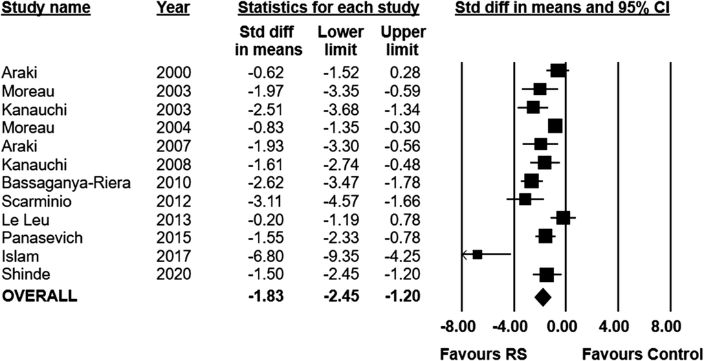

**Fig. 2** Standardized mean differences (95%) and pooled estimates for histology score (preclinical studies)

Page 9 of 14

Montroy *et al. BMC Gastroenterol (2020) 20:372*

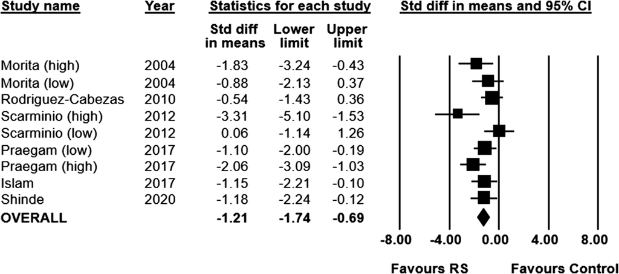

**Fig. 3** Standardized mean differences (95%) and pooled estimates for myeloperoxidase (preclinical studies)

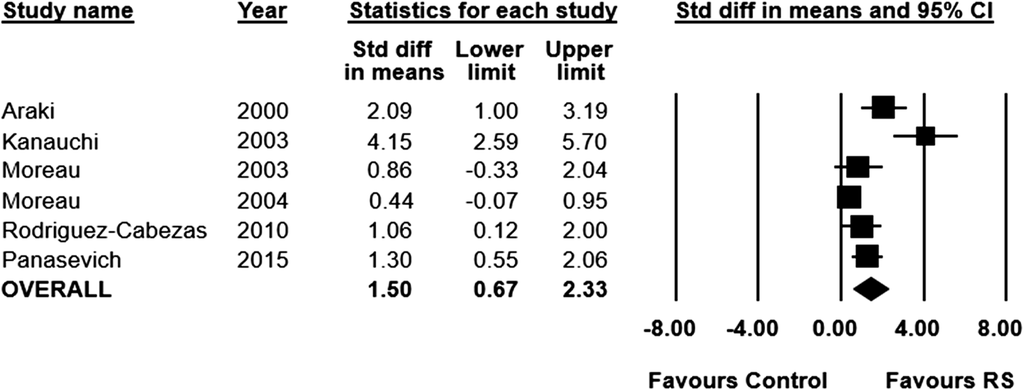

**Fig. 4** Standardized mean differences (95%) and pooled estimates for short chain fatty acid (preclinical studies)

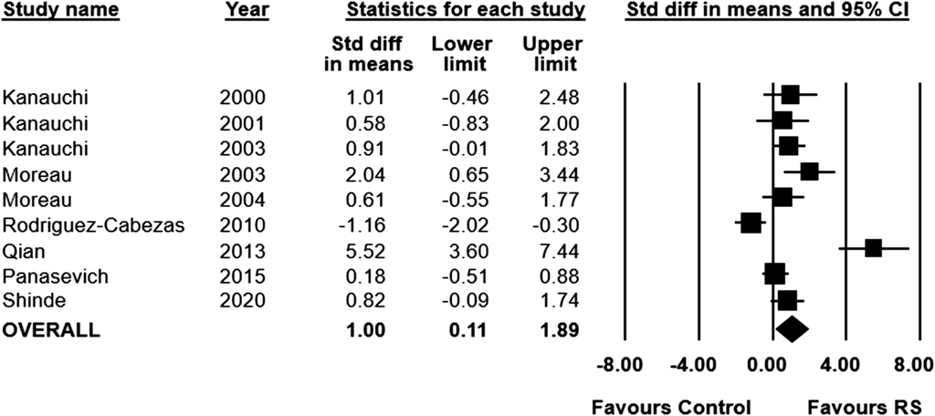

**Fig. 5** Standardized mean differences (95%) and pooled estimates for body weight (preclinical studies)

Page 10 of 14

Montroy *et al. BMC Gastroenterol (2020) 20:372*

that mice fed brown rice and retrograded brown rice

(high RS content) had a much more diverse microbiota

than the mice fed white rice-fed mice (low RS content)

[25].

**Clinical outcomes**

*Primary outcome*

Five of the included clinical studies reported on clinical

remission and response rates (n = 151 patients). Due to

the heterogeneity of study designs and outcome meas-

urement, no formal pooling of data was performed, and

clinical remission and response data is presented descrip-

tively for each of the five studies. A number of measures

were used across the five studies, including the Clinical

Activity Index (n = 4), Seo Activity Index (n = 1), recur-

rence rates (n = 1), and steroid sparing (n = 1). In two

studies that included UC patients with active disease, a

significant decrease in Clinical Activity Index scores was

observed (at two months [44] and 24 weeks [45] after

initiation of treatment). Of the three studies which were

performed in UC patients in remission, all three demon-

strated that patients remained in remission at the conclu-

sion of the study (48 days [49], 6 months [47], 12 months

[46] after initiation of treatment). One of these studies

observed a decrease from baseline in the Clinical Activ-

ity Index score, recurrence rate and steroid sparing at

*Secondary outcomes*

Due to clinical heterogeneity in the reporting of sec-

ondary outcomes, no formal statistical analysis was per-

formed, and results are presented descriptively. Four

clinical studies measured short-chain fatty acid concen-

tration, three of which showed a significant increase by

the end of the intervention period in resistant starch-fed

patients [43, 47–49]. The one study which saw no differ-

ence in overall short-chain fatty acid concentration from

baseline, did observe an increase in butyrate alone how-

ever [47].

Two studies reported measuring stool consistency and

or frequency. In one study, high RS and wheat bran was

associated with a significantly shorter whole gut transit

time in healthy control patients, but no significant differ-

ence was seen in UC participants [49]. The other study

saw a “significant correlation between the proportion of

RS and the solids recovered in effluent” [43].

One study reported levels of C-reactive protein [44].

No statistically significant change was noted, however

the authors suggested there was a trend towards decreas-

ing levels.

*Tertiary outcomes*

Adverse events were reported in four of the included

clinical studies. Two studies reported no adverse

events [44, 46]. The third study demonstrated that the

RS supplemented diet was associated with a reduc-

tion in adverse events, including complaints of diar-

rhea, abdominal pain, and gastroesophageal reflux by

the end of the study (12 weeks), when compared to a

regular diet control group [47]. The fourth study found

that “pain/cramps” and “bloating/wind” increased from

baseline in UC patients in the low RS group, whereas

the same effect was not seen in the high RS group, or

the healthy controls [49].

**Risk of bias**

The risk of bias for the preclinical studies is summa-

rized in the appendix (Additional file 1: Appendix

VI). The quality of studies was found to be poor, as all

included studies having an unclear risk of bias across

the majority of assessed domains. Adding to this,

no studies reported their randomization scheme, or

method of allocation concealment. Finally, no stud-

ies adequately described the baseline characteristics

of included animals or reported randomly housing

animals. Eight studies reporting blinding of outcome

assessment, while no studies reported blinding of

personnel.

Risk of bias for the clinical studies is summarized in

the appendix (Additional file 1: Appendix VI). Over-

all, the methodological quality of studies appears poor,

with all studies being found to be at a high risk of bias

in at least one domain. One study reported the method

of patient randomization, while none reported their

method of allocation concealment. One study reported

blinding of participants and personnel, while one study

reported blinding of outcome assessment. All stud-

ies were judged to be at a low risk of bias for attrition

bias. One study was found to be at a low risk of bias

for selective reporting while three studies were at a low

risk of other biases (conflicts of interest, funding, etc.).

A breakdown of risk of bias for each individual study

can be found in the appendix (Additional file 1: Appen-

dix VI).

**Deviations from protocol**

For clinical studies, no meta-analysis or subgroup anal-

yses were undertaken due to insufficient reporting and

clinical and methodological heterogeneity. Tertiary

outcomes of withdrawals due to adverse events and

the occurrence of serious adverse events could not be

reported in this review due to a lack of data from the

included primary studies. Planned subgroup analyses

Page 11 of 14

Montroy *et al. BMC Gastroenterol (2020) 20:372*

of animal model of IBD, dose of administration, and

inflammatory bowel disease type were not performed

due to insufficient availability data.

**Discussion**

Acute and chronic inflammation of the intestinal mucosa

defines IBD and there are a number of treatments now

available. These include dietary approaches such as

exclusive enteral nutrition and exclusion diets that have

been found to have benefit in induction therapy of mild

and moderate CD although evidence for maintenance of

remission is lacking [50, 51]. The benefit derived from

these approaches is thought to be mediated through

the intestinal microbiome, although elucidation of

such mechanisms remain largely unknown. Further-

more, given the great variance of the intestinal microbes

between different individuals in health and disease it

remains to be determined whether similar foods will have

consistent benefit.

However, overall, the results of our systematic review

and meta-analysis demonstrated that RS is associated

with reduced mucosal damage in preclinical in vivo ani-

mal models lending plausibility given the benefits of

animal models to remove confounders associated with

human disease. Most of the animal models were DSS

induced, most were in male animals and many of the

parameters studied are consistent with human disease.

Human clinical data was limited but small studies dem-

onstrate that RS maintain clinical remission in patients

with IBD and reduces the severity of symptoms associ-

ated with patients that have active disease. Additionally,

both preclinical and clinical studies found that RS was

associated with an increase in short-chain fatty acid pro-

duction. Limited clinical data suggested that RS therapy

was tolerable in IBD patients. Nonetheless, our review

has demonstrated a continuity of evidence from the pre-

clinical lab to early phase clinical trials performed to date.

Results from included clinical studies are in accordance

with similar results observed in a systematic review of RS

in a health adult population [20]. In this previous review,

supplementing the diet with RS was found to have a ben-

eficial effect on large bowel function in healthy adults, by

increasing fecal wet weight and butyrate concentration,

while decreasing fecal pH. In our current review focused

on patients with IBD, while data on fecal wet weight and

fecal pH were not reported, we did find a rise in short-

chain fatty acid concentrations (including butyrate). In

addition, our systematic review found the reporting of

The under-reporting of harms in primary studies [52,

53] is an issue that is compounded in systematic reviews

[54, 55], which can then present a misconception that

a particular treatment is safe/tolerable (RS in this sce-

nario), when the evidence is actually uncertain. Although

RS is a naturally occurring product and is likely to be

safe, further research into the safety/tolerability of RS in

an IBD population should be conducted.

Reporting of key methodological details was lacking

for the preclinical studies, with only eight studies (38%)

reporting blinding of outcome assessment, and none

reporting the randomization of animals to treatment and

control groups. This is particularly problematic as the

absence of key methodological details (i.e. randomiza-

tion and blinding), has been shown to be associated with

increased effect sizes [56, 57]. Thus, it is possible that we

are overestimating the beneficial effect of RS in the pre-

clinical setting. Similarly, clinically, our conclusions are

again limited by potentially poor methodological quality.

Only one study properly reported the randomization of

participants. While our review included single arm stud-

ies (which makes randomization irrelevant), only one

study blinded the outcome assessor, which remains possi-

ble even in single arm studies. As with preclinical studies,

the lack of proper randomization [58, 59] and blinding

[60, 61] is consistently associated with larger treatment

effects, especially when the outcomes are subjective (as

are many in IBD) [60, 61].

Statistical and methodological heterogeneity was fre-

quently observed in the included studies, and represent

a major limitation when drawing conclusions from our

data. In the preclinical studies, statistical heterogeneity

was high (77%) in the analysis of our primary outcome.

This heterogeneity was not explained by any of our sub-

group analyses (i.e. RS type/source and species). This has

the potential to be explained by individual differences

in the gut microbiome, which exist between animals,

despite of a tightly controlled laboratory environment.

Clinically, significant variability in treatment effect was

also observed. In agreement with this observation, a few

recent studies have also noted that individuals varied in

their response to RS [62–65]. These varied outcomes are

likely due to each RS having a different interaction with

each individual’s microbiota composition and/or func-

tionality. Hence, a personalized dietary intervention by

matching the type of RS to the host microbiota might be

required for beneficial effects on the host.

Clinically, we also observed significant methodological

heterogeneity with regards to study design. For example,

included in our review were four single arm studies (two

of which were cross-over studies involving multiple diets)

and three two-arm studies (one of which was a cross-

over study involving four groups, i.e. two different diets

in both IBD patients and healthy controls). Due to sig-

nificant methodological heterogeneity between studies,

we could not perform a meta-analysis, which limits our

Page 12 of 14

Montroy *et al. BMC Gastroenterol (2020) 20:372*

conclusions regarding efficacy of the treatment. It does,

however, demonstrate the paucity of data and the need

for future high-quality randomized controlled studies.

**Conclusion**

In conclusion, RS reduces histology scores within in vivo

models of IBD in preclinical studies. RS was observed

to improve clinical remission, increase short-chain fatty

events, however, this conclusion is based off of few stud-

ies that were of low quality.More research with increased

quality of methods reporting are needed to evaluate the

impact of RS on improving the underlying pathophysi-

ology of IBD. Studies should evaluate the impact of RS

alongside standard therapy as a combination treatment

to amplify the effect of treatment and consideration of

the phase of treatment may also be of importance in pro-

viding insight into the role of RS in therapy of CD and

UC.

**Supplementary information**

**Supplementary information** accompanies this paper at https ://doi.

org/10.1186/s1287 6-020-01516 -4.

**Additional file 1**. Supplementary Information.

**Abbreviations**

CD: Crohn’s disease; DSS: Dextran sulfate sodium; IBD: Inflammatory bowel

disease; IL: Interleukin; MD: Mean difference; PRESS: Peer review of electronic

search strategy; PRISMA: Preferred reporting items for systematic reviews and

meta-analyses; RS: Resistant starch; SMD: Standardized mean difference; SYR-

CLE: Systematic Review Centre for Laboratory Animal Experimentation; TNBS:

Trinitrobenzenesulfonic acid; UC: Ulcerative colitis.

**Acknowledgements**

We would like to thank Risa Shorr (Learning Services, The Ottawa Hospital) for

assisting in the creation of the literature search.

**Authors’ contributions**

DAF is acting as the guarantor of this article. JM, RB, DAF, MML, AS and DM

helped to design and refine the systematic search strategy. JM, RB, EP, CP

and LS screened selected studies for inclusion and extracted relevant data.

JM, RB, DAF and MML were involved in the analysis of the data. All authors

were involved in the interpretation of data and results. JM, RB, DAF and MML

contributed to the first draft of the manuscript. All authors contributed to the

revision and refinement of the final manuscript. All authors had full access to

all study data, have given final approval of this version of the manuscript to be

published, and agree to be accountable to all aspects of the work. All authors

read and approved the final manuscript.

**Funding**

This work was supported by the Government of Canada through Genome

Canada and the Ontario Genomics Institute (OGI-149), the Ontario Ministry

of Economic Development and Innovation (project number 13440) and the

W. Garfield Weston Foundation. The content is solely the responsibility of the

authors and does not necessarily represent the official views of the funding

bodies.

**Availability of data and materials**

All data generated or analysed during this study are included in this published

article [and its supplementary information files].

**Ethics approval and consent to participate**

Not applicable.

**Consent for publication**

Not applicable.

**Competing interests**

AS and DM are a co-founders of MedBiome, a clinical microbiomics company.

The other authors have no competing interests to disclose.

**Author details**

1 Clinical Epidemiology Program, Ottawa Hospital Research Institute, Ottawa,

Canada. <sup>2</sup> School of Epidemiology and Public Health, University of Ottawa,

Ottawa, Canada. <sup>3</sup> Department of Anesthesiology and Pain Medicine, The

Ottawa Hospital, University of Ottawa, Ottawa, Canada. <sup>4</sup> Department

of Biochemistry, Microbiology and Immunology, University of Ottawa, Ottawa,

Canada. <sup>5</sup> Inflammatory Bowel Disease Centre, Children’s Hospital of Eastern

Ontario, Ottawa, Canada. <sup>6</sup> Centre for Practice-Changing Research, Office

L1298a, 501 Smyth Road, Box 201B, Ottawa, ON K1H 8L6, Canada.

Received: 6 April 2020 Accepted: 26 October 2020

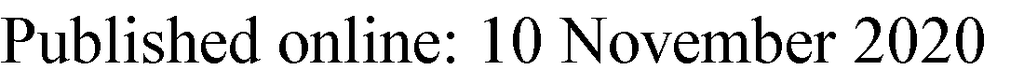

**References**

1.

Zuo T, Kamm MA, Colombel JF, Ng SC. Urbanization and the gut micro-

biota in health and inflammatory bowel disease. Nat Rev Gastroenterol

Hepatol. 2018;15(7):440–52.

2.

Molodecky NA, Soon IS, Rabi DM, Ghali WA, Ferris M, Chernoff G, et al.

Increasing incidence and prevalence of the inflammatory bowel

diseases with time, based on systematic review. Gastroenterology.

2012;142(1):46e42-54e42 (**(quiz e30)**).

3.

Nikfar S, Rahimi R, Rezaie A, Abdollahi M. A meta-analysis of the efficacy

of sulfasalazine in comparison with 5-aminosalicylates in the induction of

improvement and maintenance of remission in patients with ulcerative

colitis. Dig Dis Sci. 2009;54(6):1157–70.

4.

Khan KJ, Dubinsky MC, Ford AC, Ullman TA, Talley NJ, Moayyedi P.

Efficacy of immunosuppressive therapy for inflammatory bowel

disease: a systematic review and meta-analysis. Am J Gastroenterol.

2011;106(4):630–42.

5.

De Cassan C, Fiorino G, Danese S. Second-generation corticosteroids for

the treatment of Crohn’s disease and ulcerative colitis: more effective and

less side effects? Dig Dis. 2012;30(4):368–75.

6.

Rahimi R, Nikfar S, Abdollahi M. Do anti-tumor necrosis factors induce

response and remission in patients with acute refractory Crohn’s disease?

A systematic meta-analysis of controlled clinical trials. Biomed Pharmaco-

ther. 2007;61(1):75–80.

7.

Wong C, Harris PJ, Ferguson LR. Potential benefits of dietary fibre inter-

vention in inflammatory bowel disease. Int J Mol Sci. 2016;17(6):919.

8.

Hwang JM, Varma MG. Surgery for inflammatory bowel disease. World J

Gastroenterol. 2008;14(17):2678–90.

9.

Lim WC, Wang Y, MacDonald JK, Hanauer S. Aminosalicylates for induc-

tion of remission or response in Crohn’s disease. Cochrane Database Syst

Rev. 2016;7:CD008870.

10. Sullivan PW, Ghushchyan VH, Globe G, Schatz M. Oral corticosteroid

exposure and adverse effects in asthmatic patients. J Allergy Clin Immu-

nol. 2018;141(1):110-6e7.

11. Bryant RV, Brain O, Travis SP. Conventional drug therapy for inflammatory

bowel disease. Scand J Gastroenterol. 2015;50(1):90–112.

12. Higgins JA, Brown IL. Resistant starch: a promising dietary agent for the

prevention/treatment of inflammatory bowel disease and bowel cancer.

Curr Opin Gastroenterol. 2013;29(2):190–4.

13. Fuentes-Zaragoza E, Riquelme-Navarrete MJ, Sánchez-Zapata E, Pérez-

Álvarez JA. Resistant starch as functional ingredient: a review. Food Res

Int. 2010;43(4):931–42.

14. Goyal N, Rana A, Ahlawat A, Bijjem KR, Kumar P. Animal models of

inflammatory bowel disease: a review. Inflammopharmacology.

2014;22(4):219–33.

Page 13 of 14

Montroy *et al. BMC Gastroenterol (2020) 20:372*

15. Le Leu RK, Young GP, Hu Y, Winter J, Conlon MA. Dietary red meat aggra-

vates dextran sulfate sodium-induced colitis in mice whereas resistant

starch attenuates inflammation. Dig Dis Sci. 2013;58(12):3475–82.

16. Morita T, Tanabe H, Sugiyama K, Kasaoka S, Kiriyama S. Dietary resistant

starch alters the characteristics of colonic mucosa and exerts a protec-

tive effect on trinitrobenzene sulfonic acid-induced colitis in rats. Biosci

Biotechnol Biochem. 2004;68(10):2155–64.

17. Moreau NM, Martin LJ, Toquet CS, Laboisse CL, Nguyen PG, Siliart BS,

et al. Restoration of the integrity of rat caeco-colonic mucosa by resistant

starch, but not by fructo-oligosaccharides, in dextran sulfate sodium-

induced experimental colitis. Br J Nutr. 2003;90(1):75–85.

18. Heijnen ML, van Amelsvoort JM, Deurenberg P, Beynen AC. Limited effect

of consumption of uncooked (RS2) or retrograded (RS3) resistant starch

on putative risk factors for colon cancer in healthy men. Am J Clin Nutr.

1998;67(2):322–31.

19. Tomlin J, Read NW. The effect of resistant starch on colon function in

humans. Br J Nutr. 1990;64(2):589–95.

20. Shen D, Bai H, Li Z, Yu Y, Zhang H, Chen L. Positive effects of resistant

starch supplementation on bowel function in healthy adults: a systematic

review and meta-analysis of randomized controlled trials. Int J Food Sci

Nutr. 2017;68(2):149–57.

21. Moher D, Liberati A, Tetzlaff J, Altman DG. Preferred reporting items for

systematic reviews and meta-analyses: the PRISMA statement. PLoS Med.

2009;6(7):e1000097.

22. Sampson M, McGowan J, Cogo E, Grimshaw J, Moher D, Lefebvre C. An

evidence-based practice guideline for the peer review of electronic

search strategies. J Clin Epidemiol. 2009;62(9):944–52.

23. Hooijmans CR, Rovers MM, de Vries RB, Leenaars M, Ritskes-Hoitinga M,

Langendam MW. SYRCLE’s risk of bias tool for animal studies. BMC Med

Res Methodol. 2014;14:43.

24. Sterne JAC, Savovic J, Page MJ, Elbers RG, Blencowe NS, Boutron I, et al.

RoB 2: a revised tool for assessing risk of bias in randomised trials. BMJ.

2019;366:l4898.

25. Praengam K, Sahasakul Y, Kupradinun P, Sakarin S, Sanitchua W, Rungsipi-

pat A, et al. Brown rice and retrograded brown rice alleviate inflammatory

response in dextran sulfate sodium (DSS)-induced colitis mice. Food

Funct. 2017;8(12):4630–43.

26. Panasevich MR, Allen JM, Wallig MA, Woods JA, Dilger RN. Moderately

fermentable potato fiber attenuates signs and inflammation associated

with experimental colitis in mice. J Nutr. 2015;145(12):2781–8.

27. Islam J, Koseki T, Watanabe K, Ardiansyah SB, Budijanto S, Oikawa A, et al.

Dietary supplementation of fermented rice bran effectively alleviates

dextran sodium sulfate-induced colitis in mice. Nutrients. 2017;9(7):747.

28. Majumder K, Fukuda T, Zhang H, Sakurai T, Taniguchi Y, Watanabe H, et al.

Intervention of isomaltodextrin mitigates intestinal inflammation in a

dextran sodium sulfate-induced mouse model of colitis via inhibition of

toll-like receptor-4. J Agric Food Chem. 2017;65(4):810–7.

29. Araki Y, Kanauchi O, Sugihara H, Fujiyama Y, Hattori T. Germinated barley

foodstuff suppresses dextran sulfate experimental colitis in rats: the role

of mast cells. Int J Mol Med. 2007;19(2):257–62.

30. Qian Y, Zhao X, Song JL, Zhu K, Sun P, Li GJ, et al. Inhibitory effects

of resistant starch (RS3) as a carrier for stachyose on dextran sulfate

sodium-induced ulcerative colitis in C57BL/6 mice. Exp Ther Med.

2013;6(5):1312–6.

31. Scarminio V, Fruet AC, Witaicenis A, Rall VL, Di Stasi LC. Dietary interven-

tion with green dwarf banana flour (Musa sp AAA) prevents intestinal

inflammation in a trinitrobenzenesulfonic acid model of rat colitis. Nutr

Res (New York, NY). 2012;32(3):202–9.

32. Komiyama Y, Andoh A, Fujiwara D, Ohmae H, Araki Y, Fujiyama Y, et al.

New prebiotics from rice bran ameliorate inflammation in murine colitis

models through the modulation of intestinal homeostasis and the

mucosal immune system. Scand J Gastroenterol. 2011;46(1):40–52.

33. Rodriguez-Cabezas ME, Camuesco D, Arribas B, Garrido-Mesa N,

Comalada M, Bailon E, et al. The combination of fructooligosaccharides

and resistant starch shows prebiotic additive effects in rats. Clin Nutr

(Edinburgh, Scotland). 2010;29(6):832–9.

34. Bassaganya-Riera J, DiGuardo M, Viladomiu M, de Horna A, Sanchez S,

Einerhand AW, et al. Soluble fibers and resistant starch ameliorate disease

activity in interleukin-10-deficient mice with inflammatory bowel disease.

J Nutr. 2011;141(7):1318–25.

35. Kanauchi O, Oshima T, Andoh A, Shioya M, Mitsuyama K. Germinated

barley foodstuff ameliorates inflammation in mice with colitis through

modulation of mucosal immune system. Scand J Gastroenterol.

2008;43(11):1346–52.

36. Jacobasch G, Schmiedl D, Kruschewski M, Schmehl K. Dietary resistant

starch and chronic inflammatory bowel diseases. Int J Colorectal Dis.

1999;14(4–5):201–11.

37. Moreau NM, Champ MM, Goupry SM, Le Bizec BJ, Krempf M, Nguyen

PG, et al. Resistant starch modulates in vivo colonic butyrate uptake and

its oxidation in rats with dextran sulfate sodium-induced colitis. J Nutr.

2004;134(3):493–500.

38. Kanauchi O, Serizawa I, Araki Y, Suzuki A, Andoh A, Fujiyama Y, et al. Ger-

minated barley foodstuff, a prebiotic product, ameliorates inflammation

of colitis through modulation of the enteric environment. J Gastroenterol.

2003;38(2):134–41.

39. Kanauchi O, Iwanaga T, Andoh A, Araki Y, Nakamura T, Mitsuyama K, et al.

Dietary fiber fraction of germinated barley foodstuff attenuated mucosal

damage and diarrhea, and accelerated the repair of the colonic mucosa

in an experimental colitis. J Gastroenterol Hepatol. 2001;16(2):160–8.

40. Kanauchi O, Serizawa I, Matsumura T, Fukuda Y, Satomi M. Evalua-

tion of antigenicity of germinated barley foodstuff for the treatment

of ulcerative colitis in a chronic murine colitis model. Int J Mol Med.

2001;7(2):143–7.

41. Araki Y, Fujiyama Y, Andoh A, Koyama S, Kanauchi O, Bamba T. The dietary

combination of germinated barley foodstuff plus *Clostridium butyricum*

suppresses the dextran sulfate sodium-induced experimental colitis in

rats. Scand J Gastroenterol. 2000;35(10):1060–7.

42. Shinde T, Perera AP, Vemuri R, Gondalia SV, Beale DJ, Karpe AV, et al.

Synbiotic supplementation with prebiotic green banana resistant starch

and probiotic Bacillus coagulans spores ameliorates gut inflammation in

mouse model of inflammatory bowel diseases. Eur J Nutr. 2020. https ://

doi.org/10.1007/s0039 4-020-02200 -9.

43. Silvester KR, Englyst HN, Cummings JH. Ileal recovery of starch from

whole diets containing resistant starch measured in vitro and fer-

mentation of ileal effluent [Erratum appears in Am J Clin Nutr 1996

Mar;63(3):407]. Am J Clin Nutr. 1995;62(2):403–11.

44. Mitsuyama K, Saiki T, Kanauchi O, Iwanaga T, Tomiyasu N, Nishiyama T,

et al. Treatment of ulcerative colitis with germinated barley foodstuff

feeding: a pilot study. Aliment Pharmacol Ther. 1998;12(12):1225–30.

45. Kanauchi O, Mitsuyama K, Homma T, Takahama K, Fujiyama Y, Andoh A,

et al. Treatment of ulcerative colitis patients by long-term administration

of germinated barley foodstuff: multi-center open trial. Int J Mol Med.

2003;12(5):701–4.

46. Hanai H, Kanauchi O, Mitsuyama K, Andoh A, Takeuchi K, Takayuki I, et al.

Germinated barley foodstuff prolongs remission in patients with ulcera-

tive colitis. Int J Mol Med. 2004;13(5):643–7.

47. Hallert C, Bjorck I, Nyman M, Pousette A, Granno C, Svensson H. Increas-

ing fecal butyrate in ulcerative colitis patients by diet: controlled pilot

study. Inflamm Bowel Dis. 2003;9(2):116–21.

48. Clarke JM, Bird AR, Topping DL, Cobiac L. Excretion of starch and esteri-

fied short-chain fatty acids by ileostomy subjects after the ingestion of

acylated starches. Am J Clin Nutr. 2007;86(4):1146–51.

49. James SL, Christophersen CT, Bird AR, Conlon MA, Rosella O, Gibson PR,

et al. Abnormal fibre usage in UC in remission. Gut. 2015;64(4):562–70.

50. Levine A, Wine E, Assa A, Sigall Boneh R, Shaoul R, Kori M, et al. Crohn’s

disease exclusion diet plus partial enteral nutrition induces sus-

tained remission in a randomized controlled trial. Gastroenterology.

2019;157(2):440-50e8.

51. Mack DR, Benchimol EI, Critch J, deBruyn J, Tse F, Moayyedi P, et al. Cana-

dian Association of gastroenterology clinical practice guideline for the

medical management of pediatric luminal Crohn’s disease. J Can Assoc

Gastroenterol. 2019;2(3):e35–63.

52. Ioannidis JP. Adverse events in randomized trials: neglected, restricted,

distorted, and silenced. Arch Intern Med. 2009;169(19):1737–9.

53. Papanikolaou PN, Ioannidis JP. Availability of large-scale evidence on

specific harms from systematic reviews of randomized trials. Am J Med.

2004;117(8):582–9.

54. Zorzela L, Golder S, Liu Y, Pilkington K, Hartling L, Joffe A, et al. Quality of

reporting in systematic reviews of adverse events: systematic review. BMJ.

2014;348:f7668.

Page 14 of 14

Montroy *et al. BMC Gastroenterol (2020) 20:372*

•

•

•

•

•

•

55. McIntosh HM, Woolacott NF, Bagnall AM. Assessing harmful effects in

systematic reviews. BMC Med Res Methodol. 2004;4:19.

56. Hirst JA, Howick J, Aronson JK, Roberts N, Perera R, Koshiaris C, et al.

The need for randomization in animal trials: an overview of systematic

reviews. PLoS ONE. 2014;9(6):e98856.

57. Macleod MR, Lawson McLean A, Kyriakopoulou A, Serghiou S, de Wilde

A, Sherratt N, et al. Risk of bias in reports of in vivo research: a focus for

improvement. PLoS Biol. 2015;13(10):e1002273.

58. Sacks H, Chalmers TC, Smith H Jr. Randomized versus historical controls

for clinical trials. Am J Med. 1982;72(2):233–40.

59. Ioannidis JP, Haidich AB, Pappa M, Pantazis N, Kokori SI, Tektonidou MG,

et al. Comparison of evidence of treatment effects in randomized and

nonrandomized studies. JAMA. 2001;286(7):821–30.

60. Savovic J, Jones HE, Altman DG, Harris RJ, Juni P, Pildal J, et al. Influence

of reported study design characteristics on intervention effect estimates

from randomized, controlled trials. Ann Intern Med. 2012;157(6):429–38.

61. Hrobjartsson A, Thomsen AS, Emanuelsson F, Tendal B, Hilden J, Boutron

I, et al. Observer bias in randomised clinical trials with binary outcomes:

systematic review of trials with both blinded and non-blinded outcome

assessors. BMJ. 2012;344:e1119.

62. Baxter NT, Schmidt AW, Venkataraman A, Kim KS, Waldron C, Schmidt

TM. Dynamics of human gut microbiota and short-chain fatty acids in

response to dietary interventions with three fermentable fibers. MBio.

2019;10(1):e02566-e2618.

63. Deehan EC, Yang C, Perez-Munoz ME, Nguyen NK, Cheng CC, Triador L,

et al. Precision microbiome modulation with discrete dietary fiber struc-

tures directs short-chain fatty acid production. Cell Host Microbe. 2020.

64. Vital M, Howe A, Bergeron N, Krauss RM, Jansson JK, Tiedje JM. Metagen-

omic insights into the degradation of resistant starch by human gut

microbiota. Appl Environ Microbiol. 2018;84(23):e01562-18.

65. Yoshida N, Sasaki K, Sasaki D, Yamashita T, Fukuda H, Hayashi T, et al. Effect

of resistant starch on the gut microbiota and its metabolites in patients

with coronary artery disease. J Atheroscler Thromb. 2019;26(8):705–19.

**Publisher’s Note**

Springer Nature remains neutral with regard to jurisdictional claims in pub-

lished maps and institutional affiliations.